# EDA about ICM

```python
import numpy as np
import pandas as pd
import matplotlib as mpl
import matplotlib.pyplot as plt
```

## Asset ICM

```python
df_ICM_asset = pd.read_csv('../data/data_ICM_asset.csv')
```

```python
df_ICM_asset.head()
```

|  | row | col | data |
| --- | --- | --- | --- |
| 0 | 0 | 0 | 0.009497 |
| 1 | 1 | 0 | 0.004226 |
| 2 | 2 | 0 | 0.003371 |
| 3 | 3 | 0 | 0.002991 |
| 4 | 4 | 0 | 0.002991 |

```python
df_ICM_asset.describe()
```

|  | row | col | data |
| --- | --- | --- | --- |
| count | 18490.000000 | 18490.0 | 18490.000000 |
| mean | 9245.339102 | 0.0 | 0.008099 |
| std | 5338.957260 | 0.0 | 0.016493 |
| min | 0.000000 | 0.0 | 0.000095 |
| 25% | 4622.250000 | 0.0 | 0.002184 |
| 50% | 9244.500000 | 0.0 | 0.003989 |
| 75% | 13866.750000 | 0.0 | 0.007882 |
| max | 18494.000000 | 0.0 | 1.000000 |

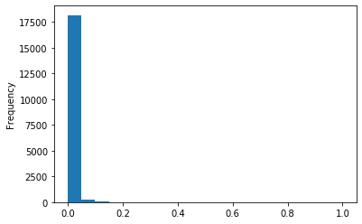

```python
df_ICM_asset['data'].plot.hist(bins=20)
```

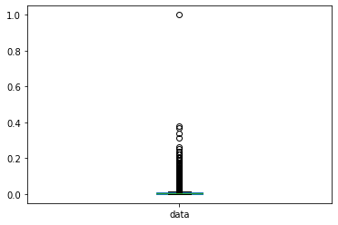

```python
df_ICM_asset['data'].plot.box()
```

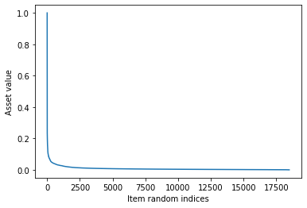

```python
plt.plot(df_ICM_asset.sort_values(by='data', ascending=False)['data'].values)
plt.xlabel("Item random indices")
plt.ylabel("Asset value")
plt.show()
```

Let's zoom in the histogram to see the distribution more or less

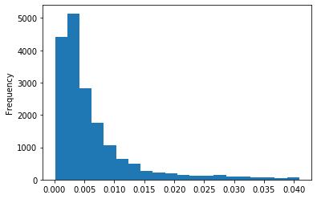

```python
asset_values = df_ICM_asset['data']
asset_values[asset_values < asset_values.mean() + asset_values.std()*2].plot.hist(bins=20)
```

Since the distribution does seem to be skewed, let's try to unskew it:

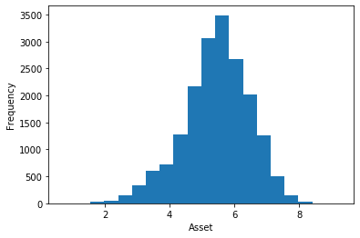

```python
transformed_asset_values = np.log1p(1/asset_values)
plt.hist(transformed_asset_values, bins=20)
plt.xlabel("Asset")
plt.ylabel("Frequency")
plt.show()
```

This transformation does transform it into a gaussian, but what if the meaning of the asset is something about how important they are for the item, then by using similarity-based algorithm, it might be a bad thing.

Regarding the missing values, we know that there are a total of 18495 items, then:

```python
item_ids = df_ICM_asset['row'].unique()
mask = np.in1d(np.arange(0, 18495), item_ids, assume_unique=True)
item_missing_ids = np.arange(0, 18495)[~mask]
item_missing_ids
```

```
array([15387, 15388, 15389, 15390, 15391])
```

```python
missing_df_ICM_asset = pd.DataFrame(data={'row': item_missing_ids,
                                          'col': np.repeat(0, len(item_missing_ids)),
                                          'data': np.repeat(df_ICM_asset['data'].mean(), len(item_missing_ids))})
new_df_ICM_asset = pd.concat([df_ICM_asset, missing_df_ICM_asset], axis=0)
new_df_ICM_asset.describe()
```

|  | row | col | data |
| --- | --- | --- | --- |
| count | 18495.00000 | 18495.0 | 18495.000000 |
| mean | 9247.00000 | 0.0 | 0.008099 |
| std | 5339.19095 | 0.0 | 0.016491 |
| min | 0.00000 | 0.0 | 0.000095 |
| 25% | 4623.50000 | 0.0 | 0.002184 |
| 50% | 9247.00000 | 0.0 | 0.004036 |
| 75% | 13870.50000 | 0.0 | 0.007882 |
| max | 18494.00000 | 0.0 | 1.000000 |

Then, after adding this missing value, we can if necessary do the **unskewing**

## Price

```python
df_ICM_price = pd.read_csv('../data/data_ICM_price.csv')
```

```python
df_ICM_price.head()
```

|  | row | col | data |
| --- | --- | --- | --- |
| 0 | 0 | 0 | 0.012911 |
| 1 | 1 | 0 | 0.005211 |
| 2 | 2 | 0 | 0.004131 |
| 3 | 3 | 0 | 0.003521 |
| 4 | 4 | 0 | 0.003521 |

```python
df_ICM_price.describe()
```

|  | row | col | data |
| --- | --- | --- | --- |
| count | 18493.000000 | 18493.0 | 18493.000000 |
| mean | 9247.255286 | 0.0 | 0.010175 |
| std | 5339.307971 | 0.0 | 0.019384 |
| min | 0.000000 | 0.0 | 0.000047 |
| 25% | 4624.000000 | 0.0 | 0.002723 |
| 50% | 9247.000000 | 0.0 | 0.005117 |
| 75% | 13871.000000 | 0.0 | 0.010047 |
| max | 18494.000000 | 0.0 | 1.000000 |

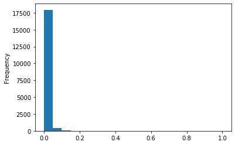

```python
df_ICM_price['data'].plot.hist(bins=20)
```

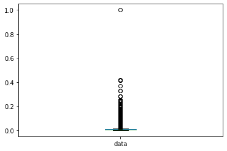

```python
df_ICM_price['data'].plot.box()
```

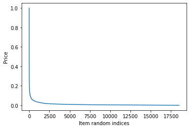

```python
plt.plot(df_ICM_price['data'].sort_values(ascending=False).values)
plt.xlabel("Item random indices")
plt.ylabel("Price")
plt.show()
```

Let's zoom in the histogram of the price

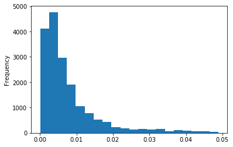

```python
price_values = df_ICM_price['data']
price_values[price_values < price_values.mean()+price_values.std()*2].plot.hist(bins=20)
plt.xlabel("")
```

Let's also try to normalize it into a gaussian, but as we have said before, the meaning of this value is unknown, so, we do not know if this preprocessing is useful or not

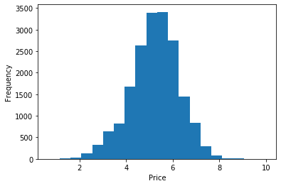

```python
transformed_price_values = np.log1p(1/price_values)
plt.hist(transformed_price_values, bins=20)
plt.ylabel("Frequency")
plt.xlabel("Price")
plt.show()
```

Let's also handle the missing values in the price ICM

```python
item_ids = df_ICM_price['row'].unique()
mask = np.in1d(np.arange(0, 18495), item_ids, assume_unique=True)
item_missing_ids = np.arange(0, 18495)[~mask]
item_missing_ids
```

```
array([ 3513, 10260])
```

```python
missing_df_ICM_price = pd.DataFrame(data={'row': item_missing_ids,
                                          'col': np.repeat(0, len(item_missing_ids)),
                                          'data': np.repeat(df_ICM_price['data'].mean(), len(item_missing_ids))})
new_df_ICM_price = pd.concat([df_ICM_price, missing_df_ICM_price], axis=0)
new_df_ICM_price.describe()
```

|  | row | col | data |
| --- | --- | --- | --- |
| count | 18495.00000 | 18495.0 | 18495.000000 |
| mean | 9247.00000 | 0.0 | 0.010175 |
| std | 5339.19095 | 0.0 | 0.019383 |
| min | 0.00000 | 0.0 | 0.000047 |
| 25% | 4623.50000 | 0.0 | 0.002723 |
| 50% | 9247.00000 | 0.0 | 0.005117 |
| 75% | 13870.50000 | 0.0 | 0.010047 |
| max | 18494.00000 | 0.0 | 1.000000 |

Then, after adding this missing value, we can if necessary do the **unskewing**

## Sub class

```python
df_ICM_sub_class = pd.read_csv('../data/data_ICM_sub_class.csv')
```

```python
df_ICM_sub_class.head()
```

|  | row | col | data |
| --- | --- | --- | --- |
| 0 | 0 | 679 | 1.0 |
| 1 | 1 | 1376 | 1.0 |
| 2 | 2 | 1495 | 1.0 |
| 3 | 3 | 502 | 1.0 |
| 4 | 4 | 502 | 1.0 |

```python
df_ICM_sub_class.describe()
```

|  | row | col | data |
| --- | --- | --- | --- |
| count | 18495.00000 | 18495.000000 | 18495.0 |
| mean | 9247.00000 | 1013.417626 | 1.0 |
| std | 5339.19095 | 584.487728 | 0.0 |
| min | 0.00000 | 1.000000 | 1.0 |
| 25% | 4623.50000 | 502.000000 | 1.0 |
| 50% | 9247.00000 | 1025.000000 | 1.0 |
| 75% | 13870.50000 | 1544.000000 | 1.0 |
| max | 18494.00000 | 2010.000000 | 1.0 |

```python
print("There are %d unique items, which means there are all of them"%len(df_ICM_sub_class['row'].unique()))
```

```
There are 18495 unique items, which means there are all of them
```

Moreover, it means that each item has only one sub class

```python
print("There are %d unique sub classes"%len(df_ICM_sub_class['col'].unique()))
```

```
There are 1905 unique sub classes
```

Many items has the same sub class, then, let's see the top popular sub classes

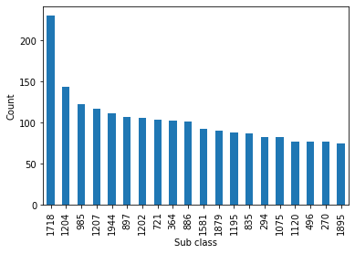

```python
df_ICM_sub_class['col'].value_counts()[:20].plot.bar()
plt.xlabel('Sub class')
plt.ylabel('Count')
plt.show()
```

Let's also see the least populars

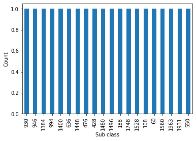

```python
df_ICM_sub_class['col'].value_counts()[-20:].plot.bar()
plt.xlabel('Sub class')
plt.ylabel('Count')
plt.show()
```

Many sub classes are paired to only 1 items, let's see how many of them

```python
counts = df_ICM_sub_class['col'].value_counts()
print("There are %d sub classes with only one items paired"%len(counts[counts==1]))
```

```
There are 410 sub classes with only one items paired
```

We can also see a boxplot for more information

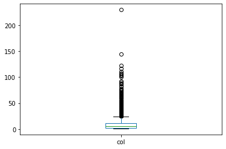

```python
counts.plot.box()
```